Inicio

# Anotación celular

Clase 3 de 4 · Módulo scRNA-seq + CITE-seq

Autor/a

Dr. Danilo Ceschin

Fecha de publicación

22 de septiembre de 2026

**NotaQué es este documento**

Es el **script de esta clase, ya ejecutado**: el mismo código que ejecutas en tu computadora, con sus resultados y sus figuras tal como salieron.

Sirve para dos cosas. Durante la práctica, para comparar: si tu salida no se parece a la de acá, algo pasó y conviene mirarlo. Y después de la clase, como material de estudio, porque el texto explicativo y los resultados están juntos.

**Para trabajar, abre el archivo `.R` en RStudio**, no este documento. El código es idéntico línea por línea. Antes de nada, doble clic en `Curso_scRNAseq.Rproj`: eso fija el directorio de trabajo, y sin eso las rutas relativas `data/` y `results/` no funcionan.

Tenemos clusters numerados. Hoy les ponemos nombre.

Parece el paso trivial del pipeline y es el más difícil de todos, por una razón conceptual: decir *“el cluster 4 son monocitos CD14+”* **no es un resultado, es una hipótesis**. Es una afirmación sobre identidad biológica derivada de una medición de ARNm, mediada por decisiones de preprocesamiento que tomamos nosotros en las clases 1 y 2.

Todo el resto del análisis va a apoyarse en esos nombres. Si están mal, todo lo que sigue está mal, y —a diferencia de un error de código— nada va a fallar ruidosamente.

### Objetivos de la clase

1. Usar marcadores canónicos y conocer sus límites en scRNA-seq.
2. Anotar automáticamente con **SingleR + celldex** (API nueva `fetchReference`), por célula y por cluster.
3. Mapear contra una referencia curada (**reference mapping**) y comparar los tres métodos.
4. Diagnosticar **RNA ambiental** y otros confundidores que producen anotaciones falsas.
5. Reportar la anotación con un **nivel de confianza explícito**.

## 0. Preparación del entorno

Este bloque prepara el entorno local: crea las carpetas del proyecto, instala lo que falte e importa los paquetes. La instalación completa puede tardar la primera vez; después arranca en segundos.

#### 0.1 Carpetas de trabajo y rutas

Todo lo que el script descarga o produce vive dentro del proyecto:

```
  data/     matrices descargadas de 10x Genomics (se bajan una sola vez)
  results/  checkpoints .rds y tablas de resultados
  figures/  figuras exportadas con guardar_fig()
```

Estas carpetas viven en el disco, dentro del proyecto: NO se borran al cerrar RStudio. El checkpoint que guarda cada clase queda disponible para la siguiente.

```r
dir_datos <- "data"
dir_res   <- "results"
dir_fig   <- "figures"
for (d in c(dir_datos, dir_res, dir_fig)) {
  if (!dir.exists(d)) dir.create(d, recursive = TRUE)
}

# Rutas usadas a lo largo de las cuatro clases
f_h5_filt <- file.path(dir_datos, "pbmc10k_filtered.h5")   #  21 MB
f_h5_raw  <- file.path(dir_datos, "pbmc10k_raw.h5")        # 154 MB (solo clase 4)
ck1 <- file.path(dir_res, "clase1_pbmc_reducido.rds")
ck2 <- file.path(dir_res, "clase2_pbmc_clusterizado.rds")
ck3 <- file.path(dir_res, "clase3_pbmc_anotado.rds")
ck4 <- file.path(dir_res, "clase4_pbmc_multimodal.rds")

# Tamaño de archivo sin depender del shell del sistema: funciona igual en
# macOS, Linux y Windows.
tam_archivo <- function(f) {
  if (!file.exists(f)) {
    cat("[falta]", f, "\n")
  } else {
    cat(sprintf("%s - %.1f MB\n", f, file.size(f) / 1024^2))
  }
  invisible(file.exists(f))
}

# Exportar una figura al directorio figures/
guardar_fig <- function(p, nombre, w = 12, h = 6, dpi = 150) {
  ggplot2::ggsave(file.path(dir_fig, nombre), p, width = w, height = h, dpi = dpi)
  cat("figura guardada en", file.path(dir_fig, nombre), "\n")
}
```

#### 0.2 Paquetes

Instalación condicional: solo se instala lo que falta. La primera vez puede tardar bastante (Seurat y sus dependencias compilan código C++); las siguientes veces este bloque termina en segundos.

REQUISITOS DEL SISTEMA (una sola vez, fuera de R):

```
  - macOS  : instalar las Command Line Tools (`xcode-select --install`) y
             HDF5 (`brew install hdf5`), que es lo que necesita `hdf5r`
             para leer los archivos .h5 de 10x.
  - Linux  : `sudo apt install libhdf5-dev libcurl4-openssl-dev libssl-dev
             libxml2-dev libfontconfig1-dev libharfbuzz-dev libfribidi-dev`
  - Windows: instalar Rtools de la misma versión mayor que tu R.
```

Si `hdf5r` no compila, la alternativa es bajar el .tar.gz de la matriz desde 10x y usar Read10X() en lugar de Read10X_h5().

```r
instalar_si_falta <- function(pkgs, fuente = c("CRAN", "Bioconductor")) {
  fuente <- match.arg(fuente)
  faltan <- pkgs[!vapply(pkgs, requireNamespace, logical(1), quietly = TRUE)]
  if (!length(faltan)) return(invisible(NULL))
  message("Instalando desde ", fuente, ": ", paste(faltan, collapse = ", "))
  if (fuente == "CRAN") {
    install.packages(faltan)
  } else {
    BiocManager::install(faltan, ask = FALSE, update = FALSE)
  }
}

if (!requireNamespace("BiocManager", quietly = TRUE)) install.packages("BiocManager")
if (!requireNamespace("remotes",     quietly = TRUE)) install.packages("remotes")

instalar_si_falta(c("Seurat", "SeuratObject", "hdf5r", "tidyverse", "patchwork",
                    "cowplot", "ggridges", "pheatmap", "clustree", "R.utils",
                    "viridis", "gridExtra", "ggrepel"), "CRAN")

# Nota sobre `scrapper`, `viridis` y `gridExtra`: SingleR los declara en
# Suggests, no en Imports, así que NO se instalan junto con SingleR. Hacen falta
# igual en la clase 3: `scrapper` para SingleR(clusters = ...) y los otros dos
# para plotScoreHeatmap() y plotDeltaDistribution(). Sin ellos el error aparece
# recién en medio de la práctica, así que se instalan acá.
instalar_si_falta(c("SingleCellExperiment", "scuttle", "scDblFinder",
                    "SingleR", "celldex", "glmGamPoi", "scrapper"), "Bioconductor")

# presto acelera ~100x el test de Wilcoxon de FindAllMarkers. No está en CRAN.
if (!requireNamespace("presto", quietly = TRUE)) {
  remotes::install_github("immunogenomics/presto", upgrade = "never")
}

suppressPackageStartupMessages({
  library(Seurat); library(SeuratObject); library(tidyverse)
  library(patchwork); library(cowplot)
})

cat("Seurat:", as.character(packageVersion("Seurat")), "\n")
```

```
#> Seurat: 5.5.1
```

```r
cat("R:", R.version.string, "\n")
```

```
#> R: R version 4.5.2 (2025-10-31)
```

El tamaño de las figuras lo define el panel Plots de RStudio. Para ver una figura en grande: botón “Zoom”. Para exportarla: guardar_fig().

```r
set.seed(42)  # reproducibilidad: TODO lo que sigue depende de esto
```

## 1. Retomamos el objeto clusterizado

```r
if (file.exists(ck2)) {
  pbmc <- readRDS(ck2)
  DefaultAssay(pbmc) <- "RNA"; Idents(pbmc) <- "clusters"
  cat("Cargado:", ncol(pbmc), "células,", nlevels(pbmc$clusters), "clusters\n")
} else {
  cat("No encontrado. Ejecuta el bloque de regeneración de abajo.\n")
}
```

```
#> Cargado: 6907 células, 15 clusters
```

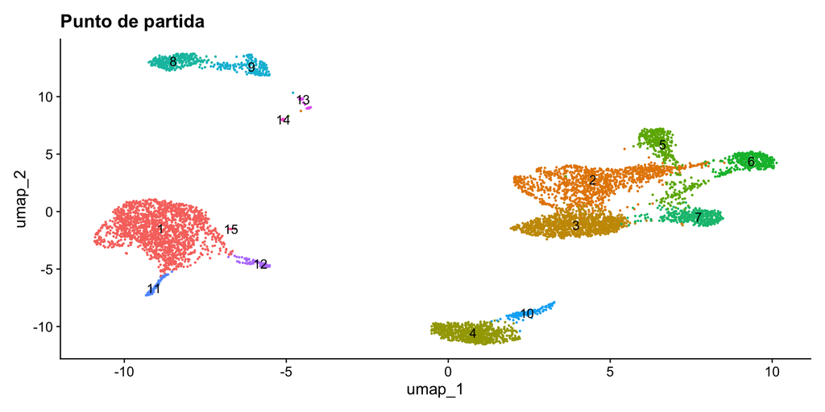

```r
# Regeneración desde cero si hace falta (~5 min).
# Reproduce los pasos de las clases 1 y 2 que importan para hoy, con los MISMOS
# parámetros: 2000 HVGs, 30 PCs, k = 20 y clustering con Leiden (igraph) a
# resolución 0.5 — el algoritmo que elegimos en la clase 2 porque corrige los
# clusters internamente desconectados de Louvain. Si aquí usáramos otro, quien
# regenera obtendría clusters distintos de quien cargó el checkpoint, y las
# etiquetas de la sección 7 no coincidirían.
if (!exists("pbmc")) {
  suppressPackageStartupMessages(library(scDblFinder))
  url_filt <- paste0("https://cf.10xgenomics.com/samples/cell-exp/3.0.0/",
                     "pbmc_10k_protein_v3/pbmc_10k_protein_v3_filtered_feature_bc_matrix.h5")
  if (!file.exists(f_h5_filt))
    download.file(url_filt, f_h5_filt, mode = "wb", quiet = TRUE)

  data <- Read10X_h5(f_h5_filt)
  pbmc <- CreateSeuratObject(data[["Gene Expression"]], project = "pbmc10k",
                             min.cells = 3, min.features = 200)
  pbmc[["percent.mt"]] <- PercentageFeatureSet(pbmc, pattern = "^MT-")
  io <- function(x, k = 5, hi = FALSE) { m <- median(x); d <- mad(x)
    if (hi) x > m + k * d else x < m - k * d | x > m + k * d }
  pbmc <- pbmc[, !(io(log1p(pbmc$nCount_RNA)) | io(log1p(pbmc$nFeature_RNA)) |
                   io(pbmc$percent.mt, 3, TRUE) | pbmc$percent.mt > 20)]
  sce <- scDblFinder(as.SingleCellExperiment(pbmc), verbose = FALSE)
  pbmc$doublet_score <- colData(sce)$scDblFinder.score   # lo usa el diagnóstico de §5.2
  pbmc <- pbmc[, colData(sce)$scDblFinder.class == "singlet"]
  pbmc <- NormalizeData(pbmc, verbose = FALSE) |>
          FindVariableFeatures(nfeatures = 2000, verbose = FALSE) |>
          ScaleData(verbose = FALSE) |>
          RunPCA(npcs = 50, verbose = FALSE) |>
          RunUMAP(dims = 1:30, verbose = FALSE) |>
          FindNeighbors(dims = 1:30, k.param = 20, verbose = FALSE) |>
          FindClusters(resolution = 0.5, algorithm = 4, leiden_method = "igraph",
                       verbose = FALSE)
  pbmc$clusters <- Idents(pbmc)
  cat("Regenerado:", ncol(pbmc), "células,", nlevels(pbmc$clusters), "clusters\n")
}
DimPlot(pbmc, label = TRUE) + NoLegend() + ggtitle("Punto de partida")
```

## 2. Marcadores canónicos

### 2.1. De dónde vienen

Los marcadores clásicos de inmunología (CD3, CD4, CD8, CD19, CD14…) vienen de **citometría de flujo**: son proteínas de superficie, elegidas porque son detectables con anticuerpos y porque discriminan bien.

Cuando los trasladamos a scRNA-seq medimos otra cosa: **el ARN mensajero que codifica esa proteína**. Y ahí aparecen tres problemas:

| Problema | Qué pasa |
| --- | --- |
| **Dropout** | Un gen expresado puede tener 0 conteos por azar de muestreo. `CD4` es notoriamente difícil de detectar en scRNA-seq, aunque la proteína esté ahí. |
| **ARNm ≠ proteína** | La correlación entre ambos es moderada. `CD8A` puede transcribirse sin que la proteína esté en superficie, y viceversa. |
| **Expresión compartida** | Casi ningún gen es exclusivo de un tipo celular. `NKG7` marca NK **y** T CD8 citotóxicos. |

Este es, dicho sea de paso, uno de los argumentos más fuertes a favor de CITE-seq — que vemos el jueves.

### 2.2. Panel canónico de PBMC

```r
marcadores_canonicos <- list(
  "T (pan)"          = c("CD3D", "CD3E", "TRAC"),
  "T CD4"            = c("IL7R", "CD4", "CCR7"),
  "T CD8"            = c("CD8A", "CD8B", "GZMK"),
  "NK"               = c("GNLY", "NKG7", "KLRD1", "NCAM1"),
  "B"                = c("MS4A1", "CD79A", "CD79B"),
  "Plasmablasto"     = c("MZB1", "JCHAIN", "XBP1"),
  "Monocito CD14"    = c("CD14", "LYZ", "S100A8", "S100A9"),
  "Monocito CD16"    = c("FCGR3A", "MS4A7", "CDKN1C"),
  "DC convencional"  = c("FCER1A", "CST3", "CLEC10A"),
  "DC plasmacitoide" = c("LILRA4", "IL3RA", "GZMB"),
  "Plaqueta"         = c("PPBP", "PF4"),
  "Proliferación"    = c("MKI67", "TOP2A")
)

# Nos quedamos solo con los genes presentes en el objeto
marcadores_canonicos <- lapply(marcadores_canonicos, function(g) g[g %in% rownames(pbmc)])
str(marcadores_canonicos)
```

```
#> List of 12
#>  $ T (pan)         : chr [1:3] "CD3D" "CD3E" "TRAC"
#>  $ T CD4           : chr [1:3] "IL7R" "CD4" "CCR7"
#>  $ T CD8           : chr [1:3] "CD8A" "CD8B" "GZMK"
#>  $ NK              : chr [1:4] "GNLY" "NKG7" "KLRD1" "NCAM1"
#>  $ B               : chr [1:3] "MS4A1" "CD79A" "CD79B"
#>  $ Plasmablasto    : chr [1:3] "MZB1" "JCHAIN" "XBP1"
#>  $ Monocito CD14   : chr [1:4] "CD14" "LYZ" "S100A8" "S100A9"
#>  $ Monocito CD16   : chr [1:3] "FCGR3A" "MS4A7" "CDKN1C"
#>  $ DC convencional : chr [1:3] "FCER1A" "CST3" "CLEC10A"
#>  $ DC plasmacitoide: chr [1:3] "LILRA4" "IL3RA" "GZMB"
#>  $ Plaqueta        : chr [1:2] "PPBP" "PF4"
#>  $ Proliferación   : chr [1:2] "MKI67" "TOP2A"
```

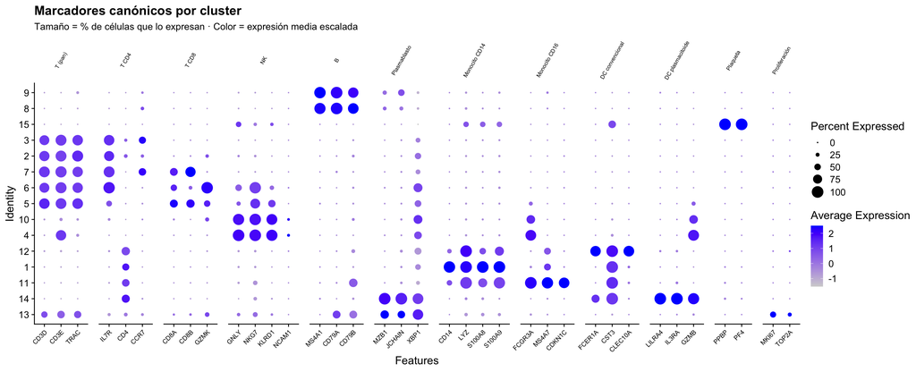

```r
DotPlot(pbmc, features = marcadores_canonicos, cluster.idents = TRUE) +
  RotatedAxis() +
  theme(axis.text.x = element_text(size = 8),
        strip.text  = element_text(size = 7, angle = 60)) +
  labs(title = "Marcadores canónicos por cluster",
       subtitle = "Tamaño = % de células que lo expresan · Color = expresión media escalada")
```

**Cómo se lee este gráfico.** Busca, para cada cluster (fila), qué bloque de marcadores se enciende. Un cluster con `CD3D`+`CD8A`+`GZMK` altos es T CD8. Un cluster con `CD14`+`LYZ`+`S100A8` es monocito clásico.

### 2.3. ¿Tipo celular o estado celular?

Antes de ponerle nombre a un cluster hay que descartar que lo que lo define no sea un **estado** en vez de un **tipo**. Un tipo celular es una identidad estable: un monocito no se convierte en linfocito. Un estado es transitorio: una célula estresada, activada o en división sigue siendo del mismo tipo.

La señal de alarma es concreta: si lo que separa a un cluster son genes de **choque térmico**, de **respuesta temprana** o de **ciclo celular**, lo más probable es que el clustering esté capturando cómo se procesó la muestra, no qué célula es.

Los genes de respuesta temprana (`FOS`, `JUN`, `EGR1`) son especialmente traicioneros: se inducen en minutos durante la disociación, así que su expresión mide **el protocolo**, no la biología del donante.

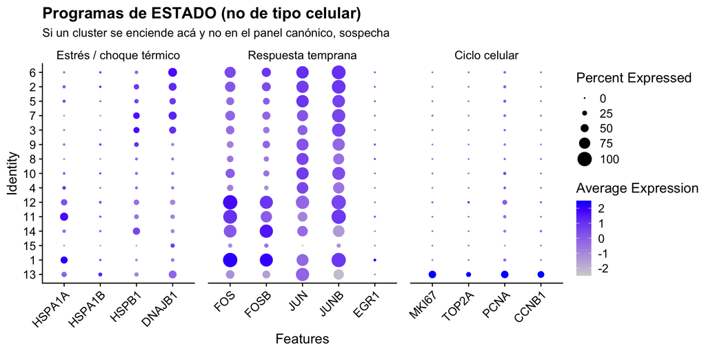

```r
programas_estado <- list(
  "Estrés / choque térmico" = c("HSPA1A", "HSPA1B", "HSPB1", "DNAJB1"),
  "Respuesta temprana"      = c("FOS", "FOSB", "JUN", "JUNB", "EGR1"),
  "Ciclo celular"           = c("MKI67", "TOP2A", "PCNA", "CCNB1")
)
programas_estado <- lapply(programas_estado, function(g) g[g %in% rownames(pbmc)])

DotPlot(pbmc, features = programas_estado, cluster.idents = TRUE) +
  RotatedAxis() +
  labs(title = "Programas de ESTADO (no de tipo celular)",
       subtitle = "Si un cluster se enciende acá y no en el panel canónico, sospecha")
```

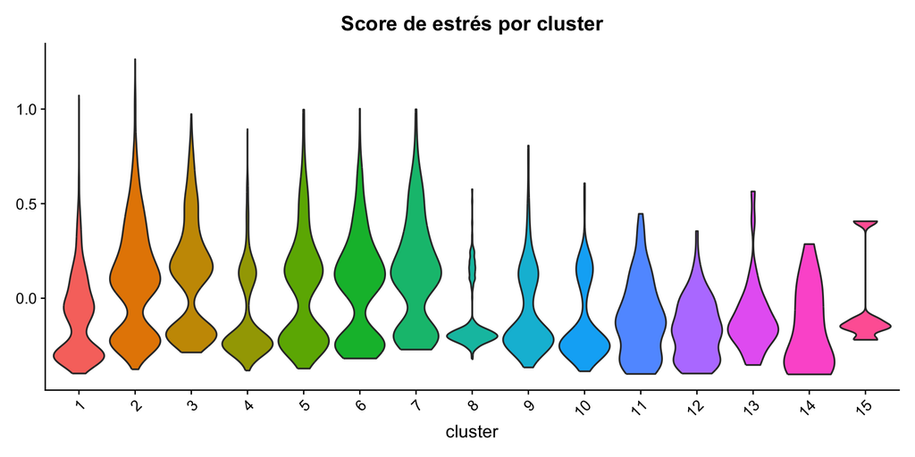

```r
# Un score por célula resume cada programa mejor que gen por gen: promedia el bloque y
# lo corrige contra genes de expresión comparable, así no confunde "programa activo" con
# "célula con más conteos".
pbmc <- AddModuleScore(pbmc, features = programas_estado["Estrés / choque térmico"],
                       name = "score_estres", seed = 42)

VlnPlot(pbmc, "score_estres1", group.by = "clusters", pt.size = 0) +
  NoLegend() + labs(title = "Score de estrés por cluster", x = "cluster")
```

> **Cómo se interpreta.** En este dataset —PBMC de donante sano, procesadas en fresco— ningún cluster debería destacarse. Si mañana analizas un tejido sólido disociado en caliente, este mismo gráfico va a mostrar un cluster entero encendido: ese cluster no es un tipo celular, es el daño del protocolo. La decisión ahí no es anotarlo, es volver al diseño experimental.

> **En nuestros datos**, el DotPlot de estado muestra dos cosas distintas. Los genes de respuesta temprana (`FOS`, `JUNB`) aparecen en TODOS los clusters, algo más en los mieloides: es el piso que deja cualquier protocolo, y como es parejo no separa a nadie. El ciclo celular, en cambio, se enciende en un solo cluster, el de los plasmablastos. Ahí el estado (proliferación) es biología real superpuesta a un tipo celular: los plasmablastos son células que se están dividiendo. Estado no siempre quiere decir artefacto; quiere decir que no alcanza para definir un tipo.

Fíjate también en lo que **no** es limpio: es habitual que un cluster tenga señal intermedia de dos bloques. Eso puede ser (a) un estado de transición real, (b) doublets remanentes, o (c) RNA ambiental. Volvemos a esto en la sección 5.

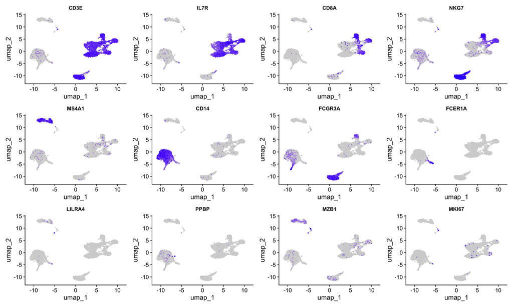

```r
FeaturePlot(pbmc, ncol = 4, order = TRUE,
            features = c("CD3E", "IL7R", "CD8A", "NKG7",
                         "MS4A1", "CD14", "FCGR3A", "FCER1A",
                         "LILRA4", "PPBP", "MZB1", "MKI67")) &
  theme(plot.title = element_text(size = 11)) & NoLegend()
```

## 3. Anotación automática: SingleR + celldex

`SingleR` correlaciona el perfil de cada célula con perfiles de referencia de tipos celulares purificados (bulk RNA-seq), usando solo los genes que mejor discriminan cada par de tipos.

### ⚠️ Cambio de API respecto del material de 2024

La forma antigua, que todavía circula en tutoriales y material de cursos previos:

```r
ref <- celldex::BlueprintEncodeData()          # ← forma antigua
```

`celldex` migró de `ExperimentHub` a **gypsum**, y ahora las referencias se piden **con nombre y versión**:

```r
ref <- celldex::fetchReference("blueprint_encode", "2024-02-26")
```

El cambio no es cosmético: las referencias ahora están **versionadas** (puedes reproducir exactamente un análisis de hace dos años) y traen las etiquetas mapeadas a **Cell Ontology**, lo que las hace interoperables entre estudios.

| Nombre | Contenido |
| --- | --- |
| `blueprint_encode` | Células inmunes y estromales humanas (Blueprint + ENCODE) |
| `hpca` | Human Primary Cell Atlas — cobertura amplia de tejidos |
| `monaco_immune` | Poblaciones inmunes humanas, la más fina para PBMC |
| `dice` | Database of Immune Cell Expression |
| `novershtern_hematopoietic` | Hematopoyesis humana, poblaciones progenitoras |
| `immgen`, `mouse_rnaseq` | Ratón |

```r
suppressPackageStartupMessages({ library(SingleR); library(celldex); library(SingleCellExperiment) })

# API NUEVA. La primera vez descarga y cachea (~1-2 min).
ref_bp    <- celldex::fetchReference("blueprint_encode", "2024-02-26")
ref_monaco <- celldex::fetchReference("monaco_immune",   "2024-02-26")

cat("Blueprint/ENCODE:", ncol(ref_bp), "perfiles,",
    length(unique(ref_bp$label.main)), "etiquetas principales\n")
```

```
#> Blueprint/ENCODE: 259 perfiles, 25 etiquetas principales
```

```r
cat("Monaco:", ncol(ref_monaco), "perfiles,",
    length(unique(ref_monaco$label.fine)), "etiquetas finas\n\n")
```

```
#> Monaco: 114 perfiles, 29 etiquetas finas
```

```r
print(sort(unique(ref_bp$label.main)))
```

```
#>  [1] "Adipocytes"        "Astrocytes"        "B-cells"
#>  [4] "CD4+ T-cells"      "CD8+ T-cells"      "Chondrocytes"
#>  [7] "DC"                "Endothelial cells" "Eosinophils"
#> [10] "Epithelial cells"  "Erythrocytes"      "Fibroblasts"
#> [13] "HSC"               "Keratinocytes"     "Macrophages"
#> [16] "Melanocytes"       "Mesangial cells"   "Monocytes"
#> [19] "Myocytes"          "Neurons"           "Neutrophils"
#> [22] "NK cells"          "Pericytes"         "Skeletal muscle"
#> [25] "Smooth muscle"
```

### 3.1. Por célula vs por cluster

SingleR puede trabajar de dos maneras, y la diferencia importa:

- **Por célula** (`clusters = NULL`): anota cada célula de forma independiente. Ventaja: detecta poblaciones que el clustering fusionó. Desventaja: más ruidoso, porque cada célula individual tiene poca información.
- **Por cluster** (`clusters = pbmc$clusters`): promedia el perfil del cluster y anota el promedio. Ventaja: mucho más estable. Desventaja: hereda todos los errores del clustering.

**Haz las dos.** Donde coinciden, tienes confianza alta. Donde no, hay algo que mirar.

```r
# La matriz dispersa se pasa DIRECTAMENTE.
# ⚠️ NO usar as.matrix(): en 7000 células son varios GB y R se queda sin memoria.
expr <- GetAssayData(pbmc, assay = "RNA", layer = "data")
cat("Clase de la matriz:", class(expr)[1], "— dispersa, como debe ser\n")
```

```
#> Clase de la matriz: dgCMatrix — dispersa, como debe ser
```

#### Un detalle de implementación que conviene conocer

Cuando le pasas `clusters =`, SingleR no hace nada mágico: suma los perfiles de todas las células de cada cluster y anota ese perfil agregado. Esa suma la delega en el paquete `scrapper`, que SingleR declara en Suggests y por lo tanto NO se instala automáticamente con él. Si falta, el error es:

```
    Error in loadNamespace(x) : there is no package called 'scrapper'
```

La sección 0 ya lo instala. La función de abajo agrega además un plan B: si en alguna computadora `scrapper` no compila, hace la agregación a mano y la clase sigue igual. De paso deja a la vista qué significa realmente `clusters =`.

```r
anotar_por_cluster <- function(expr, ref, labels, clusters) {
  if (requireNamespace("scrapper", quietly = TRUE)) {
    return(SingleR(test = expr, ref = ref, labels = labels, clusters = clusters))
  }
  message("scrapper no disponible: se agregan los clusters a mano.")
  cl  <- factor(clusters)
  ind <- Matrix::sparse.model.matrix(~ 0 + cl)   # células x clusters
  colnames(ind) <- levels(cl)
  SingleR(test = expr %*% ind, ref = ref, labels = labels)
}

# (a) por célula
anot_celula <- SingleR(test = expr, ref = ref_bp, labels = ref_bp$label.main)

# (b) por cluster
anot_cluster <- anotar_por_cluster(expr, ref_bp, ref_bp$label.main, pbmc$clusters)

pbmc$singler_celula <- anot_celula$pruned.labels
table(pbmc$singler_celula, useNA = "ifany")
```

```
#>
#>      B-cells CD4+ T-cells CD8+ T-cells Erythrocytes          HSC    Monocytes
#>          548         2031         1486            2            3         1834
#>     NK cells         <NA>
#>          916           87
```

```r
# Etiqueta por cluster, propagada a las células
#
# ⚠️ Trampa de R que vale la pena conocer: al indexar un vector con nombres, el
# resultado hereda los nombres del ÍNDICE, no los del vector original. Acá
# `mapa[as.character(pbmc$clusters)]` devuelve los valores correctos pero
# nombrados "0", "1", "2"... en lugar de códigos de barras. Seurat, al recibir
# un vector con nombres, intenta emparejarlos con sus células, no encuentra
# ninguno y aborta con:
#
#     Error: No cell overlap between new meta data and Seurat object
#
# La solución es nombrar el vector por célula antes de asignarlo. `unname()`
# también funciona (Seurat cae en emparejamiento posicional), pero nombrar
# explícitamente deja claro que el orden es el de las células del objeto.
mapa <- setNames(anot_cluster$pruned.labels, rownames(anot_cluster))
pbmc$singler_cluster <- setNames(mapa[as.character(pbmc$clusters)], colnames(pbmc))

data.frame(cluster         = rownames(anot_cluster),
           etiqueta        = anot_cluster$labels,
           etiqueta_pruned = anot_cluster$pruned.labels,
           n_celulas       = as.integer(table(pbmc$clusters)[rownames(anot_cluster)]))
```

| cluster | etiqueta | etiqueta_pruned | n_celulas |
| --- | --- | --- | --- |
| 1 | Monocytes | Monocytes | 1694 |
| 2 | CD4+ T-cells | CD4+ T-cells | 1184 |
| 3 | CD4+ T-cells | CD4+ T-cells | 1124 |
| 4 | NK cells | NK cells | 742 |
| 5 | CD8+ T-cells | CD8+ T-cells | 446 |
| 6 | CD8+ T-cells | CD8+ T-cells | 419 |
| 7 | CD4+ T-cells | CD4+ T-cells | 403 |
| 8 | B-cells | B-cells | 314 |
| 9 | B-cells | B-cells | 200 |
| 10 | NK cells | NK cells | 142 |

[output cut: 5 more lines]

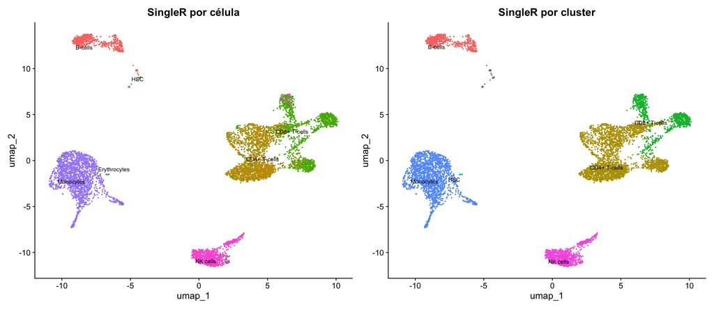

```r
(DimPlot(pbmc, group.by = "singler_celula", label = TRUE, repel = TRUE, label.size = 3) +
   ggtitle("SingleR por célula") + NoLegend()) |
(DimPlot(pbmc, group.by = "singler_cluster", label = TRUE, repel = TRUE, label.size = 3) +
   ggtitle("SingleR por cluster") + NoLegend())
```

### 3.2. Diagnóstico: no confiar en la etiqueta, mirar el score

SingleR **siempre** devuelve una etiqueta: asigna la más parecida, incluso si el parecido es malo. Hay cuatro diagnósticos que hay que mirar sí o sí:

1. **`plotScoreHeatmap`** — los scores de todas las etiquetas para cada célula. Una célula bien asignada tiene un score claramente alto para una etiqueta. Una célula ambigua tiene scores parecidos para varias.
2. **`plotDeltaDistribution`** — el delta es la diferencia entre el mejor score y la mediana de los demás. Delta chico = asignación poco confiable.
3. **`pruned.labels`** — SingleR pone `NA` a las asignaciones de baja confianza. **Esos `NA` son información, no un error a arreglar.**
4. **La tabla cluster × etiqueta** — un cluster coherente concentra sus células en una sola etiqueta. Uno repartido entre dos es una alerta.

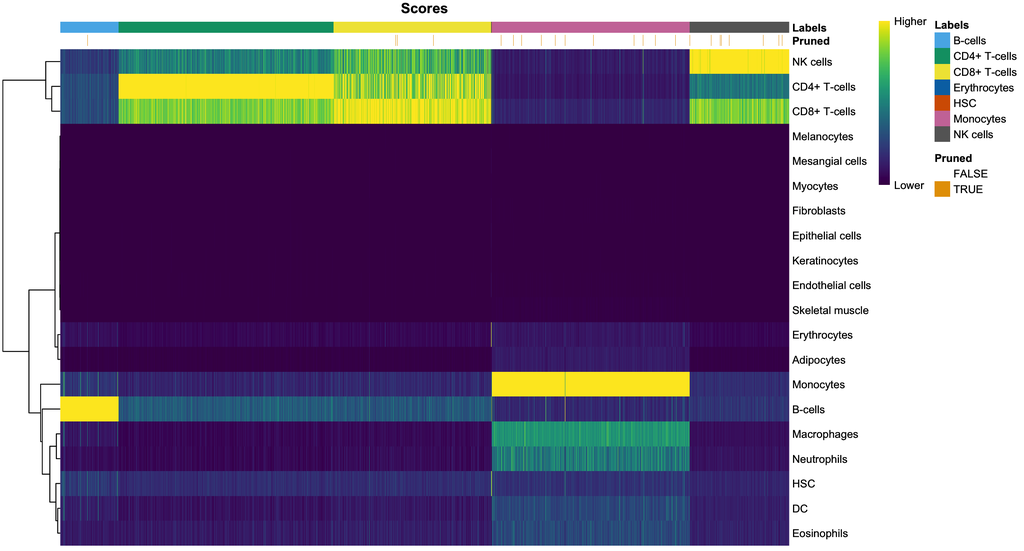

```r
plotScoreHeatmap(anot_celula, show.pruned = TRUE, max.labels = 20)
```

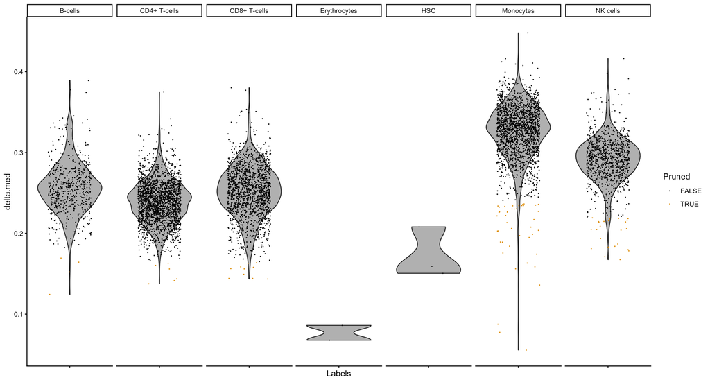

```r
plotDeltaDistribution(anot_celula, ncol = 7, size = 0.4)
```

```r
n_na <- sum(is.na(anot_celula$pruned.labels))
cat("Células descartadas por baja confianza (pruned):", n_na,
    sprintf("(%.1f %%)\n", 100 * n_na / ncol(pbmc)))
```

```
#> Células descartadas por baja confianza (pruned): 87 (1.3 %)
```

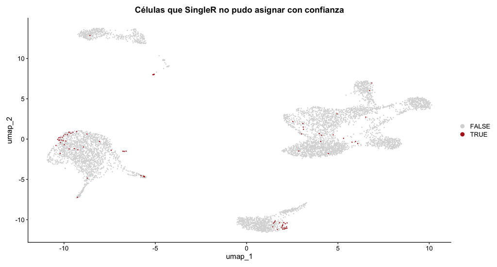

```r
# ¿Dónde están esas células en el UMAP? Casi nunca están repartidas al azar.
pbmc$sin_asignar <- is.na(pbmc$singler_celula)
DimPlot(pbmc, group.by = "sin_asignar", cols = c("grey85", "firebrick"), order = TRUE) +
  ggtitle("Células que SingleR no pudo asignar con confianza")
```

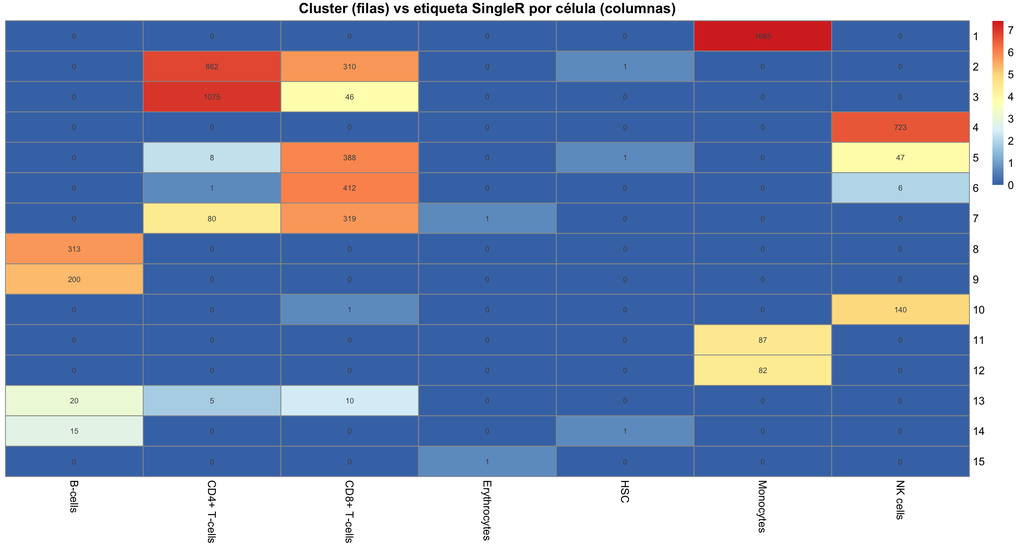

```r
# Tabla de contingencia: cluster x etiqueta. Es EL diagnóstico de coherencia.
tab <- table(cluster = pbmc$clusters, etiqueta = pbmc$singler_celula)

suppressPackageStartupMessages(library(pheatmap))
pheatmap(log1p(tab), cluster_rows = FALSE, cluster_cols = FALSE,
         display_numbers = tab, number_format = "%.0f", fontsize_number = 7,
         main = "Cluster (filas) vs etiqueta SingleR por célula (columnas)")
```

> **Cómo se lee.** Un cluster **coherente** concentra casi todas sus células en una sola columna. Un cluster repartido entre dos etiquetas es una alerta: puede ser sobre-clusterización, una población de transición, doublets, o que la referencia no contiene ese tipo celular.

> Cuando la referencia no tiene el tipo celular que estás mirando, SingleR igual asigna la etiqueta más cercana. Ese es el modo de falla más peligroso, porque el resultado se ve perfectamente razonable.

```r
# Referencia más fina para las poblaciones T, que es donde Blueprint se queda corto
anot_fina <- anotar_por_cluster(expr, ref_monaco, ref_monaco$label.fine, pbmc$clusters)

cl_ord <- rownames(anot_fina)
data.frame(cluster        = cl_ord,
           blueprint_main = anot_cluster[cl_ord, "pruned.labels"],
           monaco_fine    = anot_fina[cl_ord, "pruned.labels"])
```

| cluster | blueprint_main | monaco_fine |
| --- | --- | --- |
| 1 | Monocytes | Classical monocytes |
| 2 | CD4+ T-cells | Th1/Th17 cells |
| 3 | CD4+ T-cells | Naive CD4 T cells |
| 4 | NK cells | Natural killer cells |
| 5 | CD8+ T-cells | Non-Vd2 gd T cells |
| 6 | CD8+ T-cells | MAIT cells |
| 7 | CD4+ T-cells | Naive CD8 T cells |
| 8 | B-cells | Naive B cells |
| 9 | B-cells | Exhausted B cells |
| 10 | NK cells | Natural killer cells |

[output cut: 5 more lines]

## 4. Reference mapping

Un tercer enfoque, distinto de los dos anteriores: en lugar de correlacionar contra perfiles bulk, **proyectar nuestras células dentro del espacio de una referencia single-cell ya anotada** y transferir las etiquetas de los vecinos.

Es la lógica de **Azimuth** (referencia PBMC multimodal del laboratorio Satija, con más de 160.000 células anotadas en tres niveles jerárquicos). Por debajo son las funciones `FindTransferAnchors` + `TransferData` de Seurat — exactamente las mismas que se usan para transferir etiquetas entre scATAC-seq y scRNA-seq. Conviene ver la mecánica hoy.

**Ventajas:** la referencia es single-cell (no bulk), tiene jerarquía de niveles, y devuelve un score de predicción por célula. **Desventajas:** solo sirve si existe una referencia del tejido que estás estudiando, y hereda todos los sesgos de esa referencia.

```r
# Azimuth descarga una referencia grande. Si el tiempo aprieta, salta a la sección 5.
instalar_azimuth <- FALSE   # ← pon TRUE para ejecutarlo

if (instalar_azimuth) {
  if (!requireNamespace("Azimuth", quietly = TRUE))
    remotes::install_github("satijalab/azimuth", upgrade = "never", quiet = TRUE)
  suppressPackageStartupMessages(library(Azimuth))
  pbmc <- RunAzimuth(pbmc, reference = "pbmcref")
  head(pbmc@meta.data[, grep("predicted", colnames(pbmc@meta.data))])
} else {
  cat("Azimuth desactivado. Abajo hacemos la misma idea 'a mano' con FindTransferAnchors.\n")
}
```

```
#> Azimuth desactivado. Abajo hacemos la misma idea 'a mano' con FindTransferAnchors.
```

### 4.1. La mecánica, a mano

Para ver qué hace Azimuth por debajo, hagamos transferencia de etiquetas usando como “referencia” una mitad de los datos, con las etiquetas **por célula** de SingleR (§3.1), y prediciendo la otra mitad. Es un ejercicio artificial, pero muestra las funciones que importan y permite **medir** qué tan bien funciona el método, porque conocemos la respuesta.

¿Por qué las etiquetas por célula y no las por cluster? Las etiquetas por cluster son, por construcción, una función del grafo de vecinos: transferirlas es casi trivial (concordancia ~99 %, score 1 en todas las células) y el ejercicio no enseña nada. Las etiquetas por célula tienen la incertidumbre real de la anotación, y el score de predicción la hace visible.

```r
set.seed(11)
idx <- sample(colnames(pbmc), floor(ncol(pbmc) / 2))
ref_obj   <- subset(pbmc, cells = idx)
query_obj <- subset(pbmc, cells = setdiff(colnames(pbmc), idx))

ref_obj <- ref_obj |> NormalizeData(verbose = FALSE) |>
  FindVariableFeatures(verbose = FALSE) |> ScaleData(verbose = FALSE) |>
  RunPCA(npcs = 30, verbose = FALSE)
query_obj <- NormalizeData(query_obj, verbose = FALSE)

anchors <- FindTransferAnchors(reference = ref_obj, query = query_obj,
                               dims = 1:30, reduction = "pcaproject", verbose = FALSE)

# Las etiquetas de referencia no pueden tener NA: TransferData las trataría como
# una categoría inválida. Los clusters que SingleR dejó sin asignar (pruned) pasan
# a ser una etiqueta explícita, "Sin asignar", que también se transfiere.
# (El aviso "Different features in new layer data..." que aparece al preparar
# la referencia es inofensivo: ScaleData recalcula sobre los HVGs de esta mitad.)
etiq_ref <- as.character(ref_obj$singler_celula)
etiq_ref[is.na(etiq_ref)] <- "Sin asignar"

pred <- TransferData(anchorset = anchors, refdata = etiq_ref,
                     dims = 1:30, verbose = FALSE)

query_obj <- AddMetaData(query_obj, pred)
head(pred[, 1:3])
```

|  | predicted.id | prediction.score.Monocytes | prediction.score.Sin.asignar |
| --- | --- | --- | --- |
| AAACCCAAGATTGTGA-1 | Monocytes | 1 | 0.00000000 |
| AAACCCAGTACCGCGT-1 | Monocytes | 1 | 0.00000000 |
| AAACCCAGTCGTCATA-1 | NK cells | 0 | 0.00000000 |
| AAACCCAGTGCAAGAC-1 | Monocytes | 1 | 0.00000000 |
| AAACCCAGTGCATTTG-1 | Monocytes | 1 | 0.00000000 |
| AAACCCATCCGATGTA-1 | CD4+ T-cells | 0 | 0.03605634 |

```r
# ⚠️ Cómo se llaman las columnas del resultado: depende de cómo llamaste a
# `TransferData`, y es una fuente clásica de confusión.
#
#   TransferData(anchorset, refdata = <vector>)          ← lo que hicimos acá
#       devuelve un data.frame con:
#         predicted.id                 etiqueta predicha
#         prediction.score.<etiqueta>  una columna por etiqueta posible
#         prediction.score.max         el score de la etiqueta ganadora
#
#   TransferData(anchorset, refdata = list(id = <vector>), query = obj)
#       devuelve el OBJETO, con la metadata predicted.id y predicted.id.score.
#       Es la convención que usan Azimuth y MapQuery, donde vas a ver nombres
#       como `predicted.celltype.l2.score`.
#
# Los dos caminos dan lo mismo; solo cambia el nombre de la columna del score.
cat("Columnas devueltas:", paste(colnames(pred), collapse = ", "), "\n\n")
```

```
#> Columnas devueltas: predicted.id, prediction.score.Monocytes, prediction.score.Sin.asignar, prediction.score.B.cells, prediction.score.CD8..T.cells, prediction.score.CD4..T.cells, prediction.score.NK.cells, prediction.score.HSC, prediction.score.Erythrocytes, prediction.score.max
```

```r
etiq_query <- as.character(query_obj$singler_celula)
etiq_query[is.na(etiq_query)] <- "Sin asignar"
concordancia <- mean(query_obj$predicted.id == etiq_query)
cat("Concordancia con la anotación original:", round(100 * concordancia, 1), "%\n\n")
```

```
#> Concordancia con la anotación original: 93.2 %
```

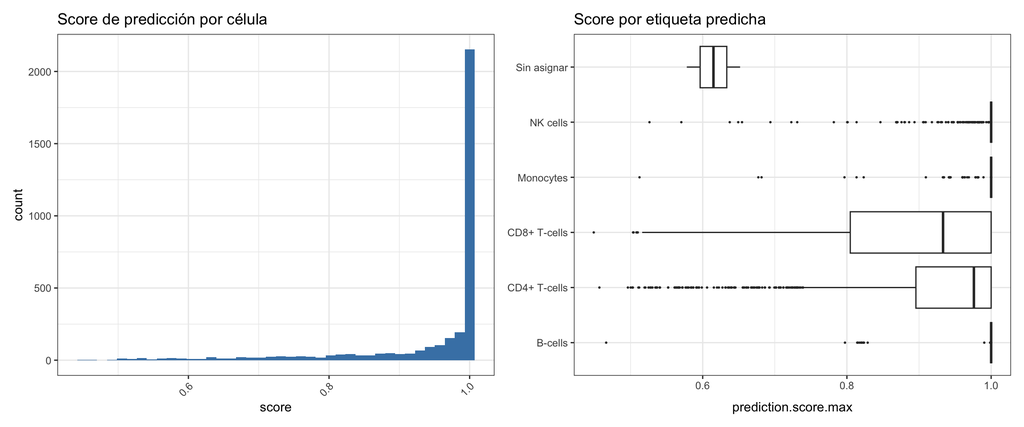

```r
p1 <- ggplot(query_obj@meta.data, aes(prediction.score.max)) +
  geom_histogram(bins = 40, fill = "steelblue") +
  labs(title = "Score de predicción por célula", x = "score") + theme_bw() +
  theme(axis.text.x = element_text(angle = 45, hjust = 1))
p2 <- ggplot(query_obj@meta.data, aes(predicted.id, prediction.score.max)) +
  geom_boxplot(outlier.size = .3) + coord_flip() +
  labs(title = "Score por etiqueta predicha", x = NULL) + theme_bw()
p1 | p2
```

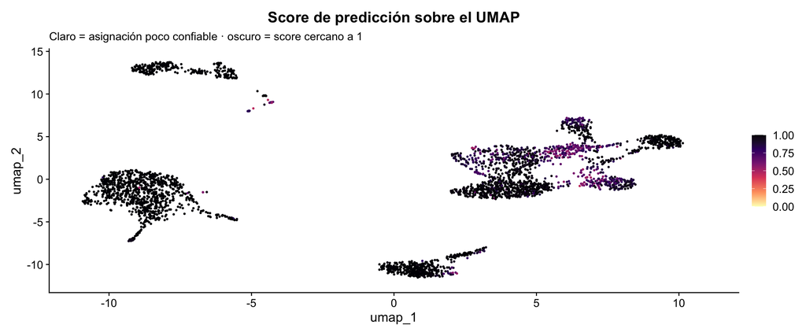

```r
# ¿Dónde están las células con score bajo? La mitad "query" conserva el UMAP
# del objeto completo, así que se puede pintar directamente.
FeaturePlot(query_obj, "prediction.score.max", reduction = "umap", pt.size = 0.4) +
  scale_colour_viridis_c(option = "magma", direction = -1, limits = c(0, 1),
                         oob = scales::squish) +
  labs(title = "Score de predicción sobre el UMAP",
       subtitle = "Claro = asignación poco confiable · oscuro = score cercano a 1")
```

> **Lo importante no es la concordancia global**, sino que el score identifica *dónde* el método es confiable. Las etiquetas con score bajo y disperso son justamente las poblaciones que hay que revisar a mano.

### 4.2. El panorama completo de métodos (2026)

| Familia | Ejemplos | Qué asume | Cuándo usarlo |
| --- | --- | --- | --- |
| Correlación con bulk | **SingleR** + celldex | La referencia contiene el tipo celular | Primera pasada, siempre |
| Reference mapping | **Azimuth**, `TransferData` | Existe referencia single-cell del tejido | Tejidos bien caracterizados (PBMC, médula, pulmón) |
| Clasificador entrenado | **CellTypist** (Python) | El modelo vio tipos similares | Inmunología; modelos preentrenados de bajo y alto nivel |
| Consenso | **popV** | Varios métodos, se mide el acuerdo | Cuando la confianza importa más que la velocidad |
| Modelos fundacionales | **scGPT**, **Geneformer** | Preentrenamiento a gran escala transfiere | Ver abajo ⚠️ |

**Sobre los modelos fundacionales.** Es el tema de moda y hay que tener una opinión informada. Los benchmarks independientes publicados en 2025–2026 (por ejemplo el framework BioLLM, en *Patterns*) muestran de forma consistente que en anotación de tipo celular **zero-shot** estos modelos **no superan de manera confiable** a métodos clásicos que son órdenes de magnitud más baratos. Con fine-tuning sobre datos del dominio mejoran, pero entonces ya no son “zero-shot” y compiten en igualdad de condiciones con un clasificador entrenado.

Conclusión para la práctica: es un área de investigación muy activa y vale la pena seguirla, pero en 2026 **no reemplaza** a SingleR ni a reference mapping para el trabajo de todos los días.

## 5. Confundidores que producen anotaciones falsas

Tres artefactos hacen que una anotación se vea perfecta y sea incorrecta.

### 5.1. RNA ambiental (la “sopa”)

Cuando las células se lisan durante la preparación, su ARNm queda libre en la suspensión y **se reparte en todas las gotas**. Cada célula recibe entonces un poco del transcriptoma de sus vecinas muertas.

Consecuencia directa sobre la anotación: en un PBMC, los monocitos expresan `LYZ` a niveles altísimos. La sopa lleva `LYZ` a todas las gotas, y de pronto los linfocitos T “expresan” `LYZ`. Uno concluye que hay una población T atípica. No la hay.

Diagnóstico rápido, sin instalar nada: **buscar marcadores exclusivos de un tipo celular en los clusters donde no deberían estar.**

```r
genes_sopa <- c("LYZ", "S100A8", "HBB", "PPBP")
genes_sopa <- genes_sopa[genes_sopa %in% rownames(pbmc)]

# Cuantificación: % de células de cada tipo con conteo > 0 de cada gen.
# Un violín no sirve para esto: fuera de su tipo celular estos genes valen 0 en
# casi todas las células y el violín se ve como una línea. Lo que importa es
# CUÁNTAS células tienen al menos un conteo donde no deberían.
sopa_tab <- sapply(genes_sopa, function(g) {
  ct <- GetAssayData(pbmc, layer = "counts")[g, ]
  round(100 * tapply(ct > 0, pbmc$singler_cluster, mean), 1)
})
sopa_tab
```

```
#>                LYZ S100A8  HBB  PPBP
#> B-cells        9.9    4.1  0.8   0.2
#> CD4+ T-cells   5.7    4.6  0.5   0.1
#> CD8+ T-cells   6.6    3.1  0.9   0.0
#> HSC           40.0   40.0 20.0 100.0
#> Monocytes    100.0   96.3  0.5   2.9
#> NK cells       8.0    5.0  0.7   0.1
```

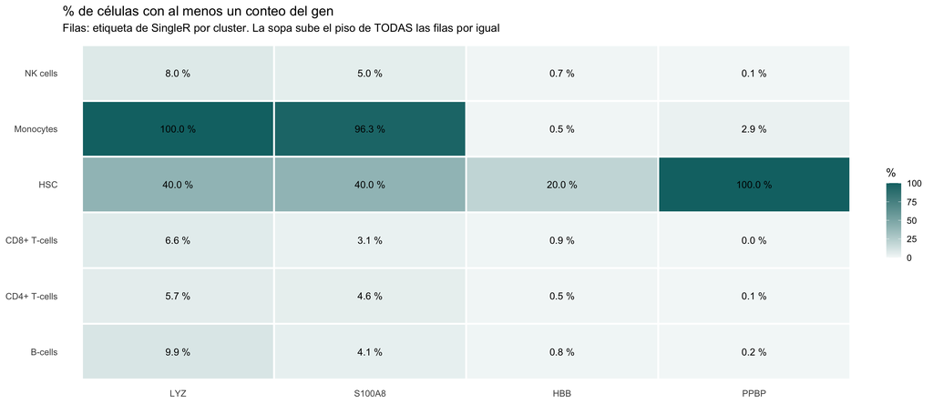

```r
sopa_df <- as.data.frame(as.table(sopa_tab))
colnames(sopa_df) <- c("tipo", "gen", "pct")

ggplot(sopa_df, aes(gen, tipo, fill = pct)) +
  geom_tile(colour = "white", linewidth = 1) +
  geom_text(aes(label = sprintf("%.1f %%", pct)), size = 4) +
  scale_fill_gradient(low = "#F4F8F8", high = "#0F7173", limits = c(0, 100)) +
  labs(title = "% de células con al menos un conteo del gen",
       subtitle = "Filas: etiqueta de SingleR por cluster. La sopa sube el piso de TODAS las filas por igual",
       x = NULL, y = NULL, fill = "%") +
  theme_minimal(base_size = 13) + theme(panel.grid = element_blank())
```

> **Cómo leerlo.** Mira la columna de `LYZ` en las filas que NO son monocitos. Ese porcentaje es el piso que pone la sopa: en datasets muy contaminados supera el 30 %. En este dataset ronda el 6–10 %, parejo en todos los linfocitos. Hay sopa, pero poca: PBMC frescas, pocas células lisadas.

> Compáralo con `PPBP` (plaquetas): casi 0 % en linfocitos y ~3 % en monocitos. Ese patrón **no** es sopa, porque la sopa llega a todas las gotas por igual. Una señal restringida a un solo tipo celular sugiere otra cosa: aquí, agregados plaqueta–monocito, que son biológicamente reales en sangre. Mismo gen “fuera de lugar”, dos explicaciones distintas: por eso se mira el patrón, no un número suelto.

> **Herramientas de corrección:** `SoupX` (estima la fracción de contaminación a partir de las gotas vacías), `DecontX` (modelo de mezcla, no necesita gotas vacías) y `CellBender` (red neuronal, Python, el más agresivo).

> **Advertencia importante**, respaldada por los benchmarks de descontaminación publicados en 2026: la corrección **no es gratis**. Algunos métodos generan conteos artificiales —agregan señal donde no había— lo cual es peor que el problema original. Recomendación práctica: **diagnosticar siempre, corregir solo si el diagnóstico lo justifica, y comparar los resultados con y sin corrección.**

### 5.2. Doublets remanentes

`scDblFinder` no atrapa todo, sobre todo los doublets homotípicos (dos células del mismo tipo, que son casi indetectables). Un doublet T+monocito aparece como una célula que expresa `CD3E` **y** `CD14`, y es fácil bautizarla como “población híbrida novel”.

Regla: antes de reportar una población que coexpresa marcadores de dos linajes, **descarta que sean doublets**.

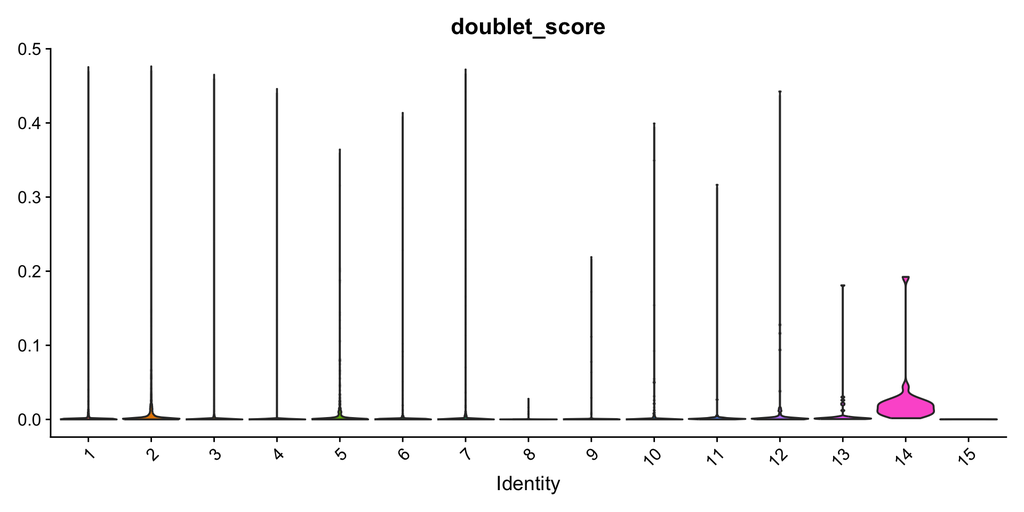

```r
# ¿Hay clusters enriquecidos en score de doublet o con perfil intermedio?
if ("doublet_score" %in% colnames(pbmc@meta.data)) {
  print(VlnPlot(pbmc, "doublet_score", group.by = "clusters", pt.size = 0) + NoLegend())
}
```

```r
# Coexpresión de linajes mutuamente excluyentes
co <- FetchData(pbmc, vars = c("CD3E", "CD14", "MS4A1", "clusters"), layer = "data")
co$doble_T_mono <- co$CD3E > 0.5 & co$CD14 > 0.5
cat("Células que coexpresan CD3E y CD14:", sum(co$doble_T_mono),
    sprintf("(%.2f %%)\n", 100 * mean(co$doble_T_mono)))
```

```
#> Células que coexpresan CD3E y CD14: 63 (0.91 %)
```

```r
round(100 * tapply(co$doble_T_mono, co$clusters, mean), 2)
```

```
#>    1    2    3    4    5    6    7    8    9   10   11   12   13   14   15
#> 2.30 0.59 0.62 0.54 0.90 0.00 0.25 0.00 0.00 0.00 1.14 0.00 0.00 0.00 0.00
```

> **Cómo leerlo.** En este dataset coexpresa menos del 1 % de las células, y el porcentaje más alto está en el cluster de monocitos CD14+. Es lo esperable de unos pocos doublets T+monocito remanentes (son los dos tipos más abundantes, así que son la combinación más probable) y no alcanza para formar un cluster propio. Si un cluster ENTERO coexpresara marcadores de dos linajes, la primera hipótesis sería doublets, no una población nueva.

### 5.3. Efectos de lote

Si el dataset tiene varias muestras y no se integró, los clusters pueden separar por **muestra** en vez de por tipo celular. Anotar en esa condición produce “tipos celulares” que son en realidad lotes.

Nuestro dataset es de un solo donante, así que no aplica. Pero es exactamente el tema de la corrección de efectos de lote, y reaparece en el análisis multimodal con Bridge Integration.

**La verificación mínima siempre es la misma:** grafica el UMAP coloreado por muestra/lote antes de anotar nada.

## 6. Ponerle el nombre correcto: ontologías

`"Mono"`, `"monocyte"`, `"CD14+ Mono"`, `"Monocito clásico"` — si cada laboratorio usa su vocabulario, los datos no se pueden comparar entre estudios.

La **[Cell Ontology (CL)](https://obophenotype.github.io/cell-ontology/)** es un vocabulario controlado, jerárquico y con identificadores estables:

- `CL:0000860` — *classical monocyte*
- `CL:0000624` — *CD4-positive, alpha-beta T cell*

Las referencias de `celldex` ya traen este mapeo, y **CZ CELLxGENE** exige anotaciones en CL para cualquier dataset que se deposite. Usar CL desde el principio hace que tu anotación sea reutilizable.

Recursos prácticos:

- **[CellGuide (CZ CELLxGENE)](https://cellxgene.cziscience.com/cellguide)** — para cada tipo celular: definición, marcadores canónicos, marcadores calculados sobre millones de células, y la posición en la jerarquía CL.
- **[CZ CELLxGENE Discover](https://cellxgene.cziscience.com/)** — buscar la expresión de un gen a través de decenas de millones de células anotadas.
- **[Human Cell Atlas](https://data.humancellatlas.org/)** — datos de referencia por tejido.

```r
# Las referencias de celldex traen las etiquetas de Cell Ontology. Monaco, que es
# la que usamos para el detalle fino, trae un identificador CL por etiqueta:
onto_monaco <- unique(data.frame(
  main = ref_monaco$label.main,
  fine = ref_monaco$label.fine,
  ont  = ref_monaco$label.ont
))
print(onto_monaco, row.names = FALSE)
```

```
#>             main                          fine        ont
#>     CD8+ T cells             Naive CD8 T cells CL:0000900
#>     CD8+ T cells    Central memory CD8 T cells CL:0000907
#>     CD8+ T cells   Effector memory CD8 T cells CL:0000913
#>     CD8+ T cells Terminal effector CD8 T cells CL:0001062
#>          T cells                    MAIT cells CL:0000940
#>          T cells                Vd2 gd T cells CL:0000798
#>          T cells            Non-Vd2 gd T cells CL:0000798
#>     CD4+ T cells     Follicular helper T cells CL:0002038
#>     CD4+ T cells            T regulatory cells CL:0000815
#>     CD4+ T cells                     Th1 cells CL:0000545
#>     CD4+ T cells                Th1/Th17 cells CL:0000912
#>     CD4+ T cells                    Th17 cells CL:0000899
#>     CD4+ T cells                     Th2 cells CL:0000546
#>     CD4+ T cells             Naive CD4 T cells CL:0000895
#>      Progenitors              Progenitor cells CL:0002043
#>          B cells                 Naive B cells CL:0000788
#>          B cells   Non-switched memory B cells CL:0000970
#>          B cells             Exhausted B cells CL:0000236
#>          B cells       Switched memory B cells CL:0000972
#>          B cells                  Plasmablasts CL:0000980
#>        Monocytes           Classical monocytes CL:0000860
#>        Monocytes        Intermediate monocytes CL:0002393
#>        Monocytes       Non classical monocytes CL:0000875
#>         NK cells          Natural killer cells CL:0000623
#>  Dendritic cells  Plasmacytoid dendritic cells CL:0000784
#>  Dendritic cells       Myeloid dendritic cells CL:0000782
#>      Neutrophils       Low-density neutrophils CL:0000096
#>        Basophils         Low-density basophils CL:0000043
#>     CD4+ T cells Terminal effector CD4 T cells CL:0001044
```

Fíjate en que dos etiquetas distintas pueden compartir identificador (Vd2 y non-Vd2 gd T cells son ambas CL:0000798, gamma-delta T cell): la ontología tiene su propio nivel de detalle, que no siempre coincide con el de la referencia.

## 7. La anotación final

Combinamos las tres fuentes de evidencia y —esto es lo que distingue una anotación seria de una automática— **declaramos el nivel de confianza**.

La regla: la etiqueta la pones tú, no el software. SingleR y Azimuth son evidencia; los marcadores canónicos son evidencia; el criterio biológico es tuyo.

```r
# Tabla de trabajo: qué dice cada método para cada cluster.
# Indexamos POR NOMBRE, nunca por posición: el orden de las filas de SingleR
# no tiene por qué coincidir con el de levels().
cl <- levels(pbmc$clusters)

# Para cada cluster, la etiqueta mayoritaria cuando se anota célula por célula,
# y qué % de las células del cluster la comparte (coherencia).
mayoritaria <- sapply(cl, function(k) {
  x <- pbmc$singler_celula[pbmc$clusters == k]
  names(which.max(table(x)))
})
coherencia <- sapply(cl, function(k) {
  x <- pbmc$singler_celula[pbmc$clusters == k]
  round(100 * mean(!is.na(x) & x == mayoritaria[k]), 1)
})

# Monaco da etiquetas finas; su etiqueta principal (label.main) sirve para
# compararla con Blueprint al mismo nivel de detalle.
fina_a_main <- setNames(ref_monaco$label.main, ref_monaco$label.fine)
fina_a_cl   <- setNames(ref_monaco$label.ont,  ref_monaco$label.fine)

resumen <- data.frame(
  cluster       = cl,
  n_celulas     = as.integer(table(pbmc$clusters)[cl]),
  bp_cluster    = anot_cluster[cl, "pruned.labels"],   # Blueprint, por cluster
  bp_celula     = mayoritaria,                         # Blueprint, mayoría por célula
  coherencia    = coherencia,                          # % de células con esa mayoría
  monaco_fina   = anot_fina[cl, "pruned.labels"],      # Monaco, por cluster
  stringsAsFactors = FALSE
)
resumen$monaco_main <- unname(fina_a_main[resumen$monaco_fina])

# Top 3 marcadores propios de cada cluster (mismo procedimiento que la clase 2)
top_mk <- FindAllMarkers(pbmc, only.pos = TRUE, min.pct = 0.4,
                         logfc.threshold = 1, verbose = FALSE) |>
  group_by(cluster) |> slice_max(avg_log2FC, n = 3) |>
  summarise(marcadores = paste(gene, collapse = ", ")) |>
  mutate(cluster = as.character(cluster))

resumen <- left_join(resumen, top_mk, by = "cluster")
print(resumen[, c("cluster", "n_celulas", "bp_cluster", "bp_celula", "coherencia",
                  "monaco_fina", "marcadores")], row.names = FALSE)
```

```
#>  cluster n_celulas   bp_cluster    bp_celula coherencia
#>        1      1694    Monocytes    Monocytes       98.3
#>        2      1184 CD4+ T-cells CD4+ T-cells       72.8
#>        3      1124 CD4+ T-cells CD4+ T-cells       95.6
#>        4       742     NK cells     NK cells       97.4
#>        5       446 CD8+ T-cells CD8+ T-cells       87.0
#>        6       419 CD8+ T-cells CD8+ T-cells       98.3
#>        7       403 CD4+ T-cells CD8+ T-cells       79.2
#>        8       314      B-cells      B-cells       99.7
#>        9       200      B-cells      B-cells      100.0
#>       10       142     NK cells     NK cells       98.6
#>       11        88    Monocytes    Monocytes       98.9
#>       12        88    Monocytes    Monocytes       93.2
#>       13        35         <NA>      B-cells       57.1
#>       14        23         <NA>      B-cells       65.2
#>       15         5          HSC Erythrocytes       20.0
#>                   monaco_fina                   marcadores
#>           Classical monocytes      CYP1B1, S100A12, S100A8
#>                Th1/Th17 cells   AQP3, AC058791.1, TNFRSF25
#>             Naive CD4 T cells          CCR7, TRABD2A, LEF1
#>          Natural killer cells        TKTL1, FGFBP2, PRSS23
#>            Non-Vd2 gd T cells            CD8A, TRGC2, CD8B
#>                    MAIT cells          SLC4A10, LTK, KLRB1
#>             Naive CD8 T cells       LINC02446, CD8B, NELL2
#>                 Naive B cells       TCL1A, IGHD, LINC02397
#>             Exhausted B cells            IGHG1, TLR10, BLK
#>          Natural killer cells           KLRC1, XCL2, CLIC3
#>       Non classical monocytes           CDKN1C, C1QA, HES4
#>       Myeloid dendritic cells           FCER1A, ENHO, PKIB
#>                  Plasmablasts          IGHA2, IGHA1, CDC20
#>  Plasmacytoid dendritic cells      CLEC4C, SCT, AC011893.1
#>              Progenitor cells LINC00853, HRASLS, LINC00989
```

> **Antes de seguir, lee la tabla fila por fila.** Tres casos que conviene encontrar:
> - Un cluster donde **Blueprint por cluster y Blueprint por célula no coinciden**. Es exactamente la situación de §3.1: el promedio del cluster dice una cosa y la mayoría de sus células, otra. ¿A quién le crees? Mira los marcadores.
> - Un cluster donde **Blueprint dice “Monocytes” y Monaco dice “dendritic cells”**. Blueprint tiene una etiqueta “DC”, pero con pocos perfiles; ante la duda, asigna el vecino más poblado. Es el modo de falla de la referencia incompleta.
> - Clusters chicos donde **Blueprint devuelve `NA`**. No es un error: la referencia no tiene plasmablastos ni DC plasmacitoides, y SingleR lo dice en vez de inventar.